# Examining Urchin Density Data

Noam Ross

February 17, 2015

[Laura Jurgens](http://laurajurgens.com/) kindly provided data on sea urchin counts to examine for underdispersion with the [cmp package](https://github.com/noamross/cmp), wich fits distributions to the [Conway-Maxell-Poisson] distribution. This is a quick spin through the data.

```r
library(cmp) #get with devtools::install_github('noamross/cmp') if needed
library(dplyr)
library(tidyr)
library(magrittr)
library(ggplot2)
library(knitr)
opts_chunk$set(cache=TRUE)
```

Let’s load and take a look at the data.

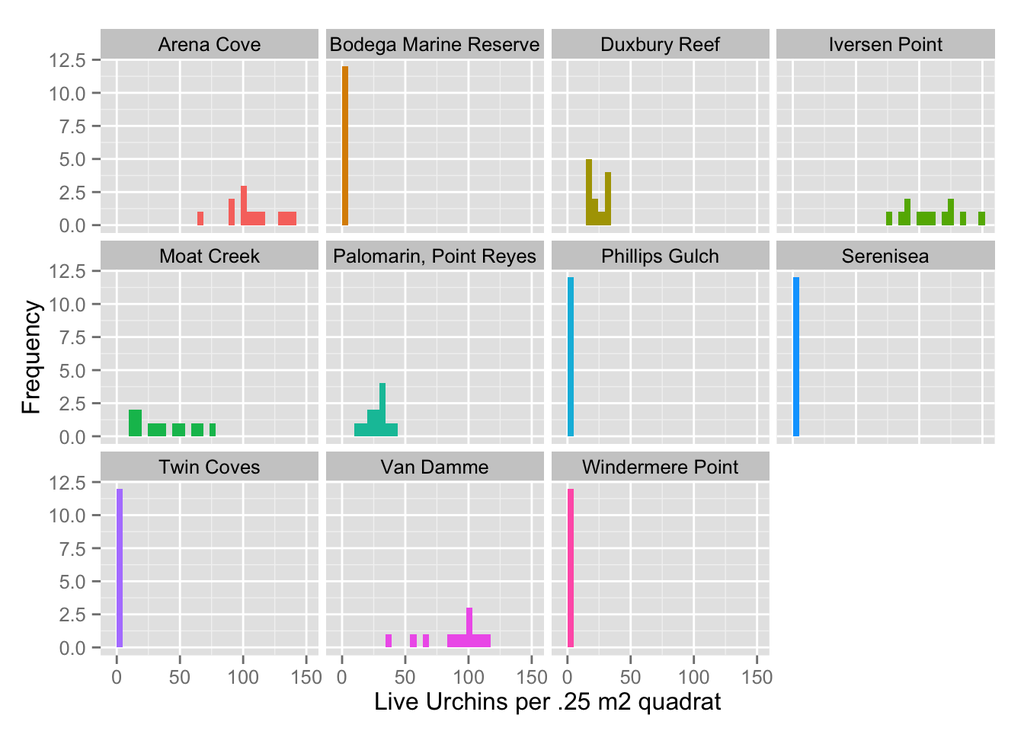

```r
urchins = as.tbl(read.csv('../../data/UrchinDensity_data_MASTER.csv'))
ggplot(urchins, aes(x = Live.per.quad, fill= Site.Name)) +
  geom_bar() +
  xlab("Live Urchins per .25 m2 quadrat") +
  theme(legend.position="none") +
  ylab("Frequency") +
  facet_wrap(~Site.Name)
```

OK, for the moment I am only interested in the data that has non-zero counts. Let’s subset those out and check the variance/mean ratios.

```r
urchins = urchins %>%
  group_by(Site.Name) %>%
  filter(sum(Live.per.quad) > 0) %>%
  droplevels()
u_sum = urchins %>% summarize(meanval = mean(Live.per.quad),
                              variance = var(Live.per.quad),
                              var_mean_ratio = variance/meanval)
kable(u_sum, digits = 2)
```

| Site.Name | meanval | variance | var_mean_ratio |
| --- | --- | --- | --- |
| Arena Cove | 106.67 | 423.33 | 3.97 |
| Duxbury Reef | 23.67 | 45.52 | 1.92 |
| Iversen Point | 109.00 | 458.36 | 4.21 |
| Moat Creek | 38.33 | 484.97 | 12.65 |
| Palomarin, Point Reyes | 28.00 | 56.18 | 2.01 |
| Van Damme | 88.42 | 580.81 | 6.57 |

It looks like all these have greater variance than mean, so they are *over* rather than underdispersed. But the CMP distribution can model overdispersed data, too, so let’s try. Here I fit Poisson, Negative Binomial, and CMP distributions to each.

```r
fits = urchins %>%
  group_by(Site.Name) %>%
  do({
    urchin_dist = table(.$Live.per.quad)
    urchin_dist = cbind(as.numeric(names(urchin_dist)), urchin_dist)
    cmp = cmp_fit(urchin_dist)
    pois = pois_fit(urchin_dist)
    nb = nb_fit(urchin_dist)
    data_frame(cmp_lambda = cmp$lambda, cmp_nu = cmp$nu, cmp_ll = cmp$log.likelihood,
               pois_lambda = pois$lambda, pois_ll = pois$log.likelihood,
               nb_mu = nb$mu, nb_size = nb$size, nb_ll = nb$log.likelihood)
  })
```

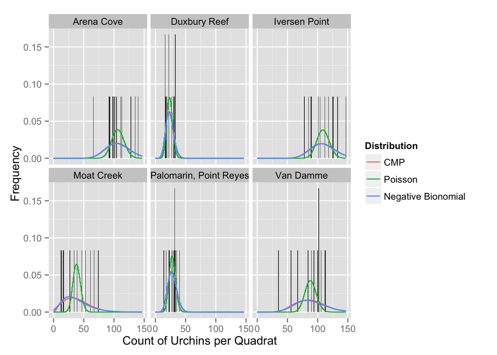

```r
max_val = max(urchins$Live.per.quad)

freqs = urchins %>%
  group_by(Site.Name) %>%
  do({freq = table(.$Live.per.quad)
      count = as.integer(names(freq))
      data_frame(freq, count)}) %>%
arrange(Site.Name, count)

sims = fits %>%
  group_by(Site.Name) %>%
  do(data_frame(count = 0:max_val,
                sim_cmp = dcmp(0:max_val, .$cmp_lambda, .$cmp_nu),
                sim_pois = dpois(0:max_val, .$pois_lambda),
                sim_nb = dnbinom(0:max_val, mu = .$nb_mu, size=.$nb_size)))
sims = full_join(sims, freqs, by = c("Site.Name", "count")) %>%
  mutate(freq = replace(freq, is.na(freq), 0)/sum(freq, na.rm=TRUE))

sims2 = sims %>%
  gather(origin, frequency, sim_cmp, sim_pois, sim_nb, freq)
ggplot(sims) +
  geom_bar(mapping = aes(x = count, y = frequency),
           data = filter(sims2, origin=="freq"),
           stat="identity", position="identity") +
  geom_step(mapping = aes(x = count - 0.5, y = frequency, col=origin),
            data = filter(sims2, origin!="freq")) +
  scale_color_discrete(name='Distribution', labels=c("CMP", "Poisson", "Negative Bionomial")) +
  facet_wrap(~Site.Name, ncol=3) +
  xlab('Count of Urchins per Quadrat') +
  ylab('Frequency')
```

Both CMP and Negative Binomial produce wider estimated distributions than the Poisson. Is either better? Let’s look at the AIC statistics for each distribution at each site, which tells us which distribution better predicts the data, adjusting for model complexity. (Both negative bionmial and CMP distributions have 2 parameters, while Poisson only has 1).

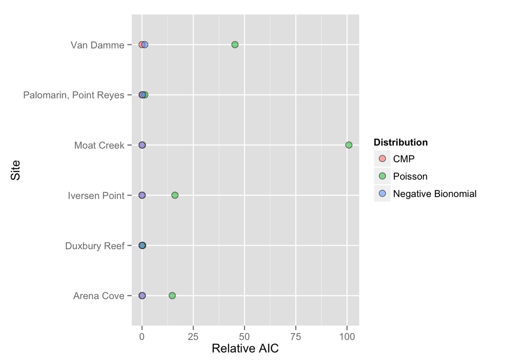

```r
fits = fits %>%
  mutate(cmp_AIC = 4 - 2*cmp_ll, pois_AIC = 2 - 2*pois_ll, nb_AIC = 4 - 2*nb_ll)
aictab = fits %>%
  select(ends_with("AIC")) %>%
  gather("distribution", "AIC", ends_with("AIC")) %>%
  group_by(Site.Name) %>%
  mutate(rel_AIC = AIC - min(AIC)) %>%
  arrange(Site.Name)

ggplot(aictab, aes(x=rel_AIC, y=Site.Name, fill=distribution)) +
  geom_point(size=3, alpha=0.5, pch=21, col="black") +
  scale_fill_discrete(name="Distribution", labels=c("CMP", "Poisson", "Negative Bionomial")) +
  xlab("Relative AIC") + ylab("Site")
```

Both the CMP and Negative Binomial fits are always better (have lower AIC) than the Poisson. Let’s zoom in and see how they compare to each other:

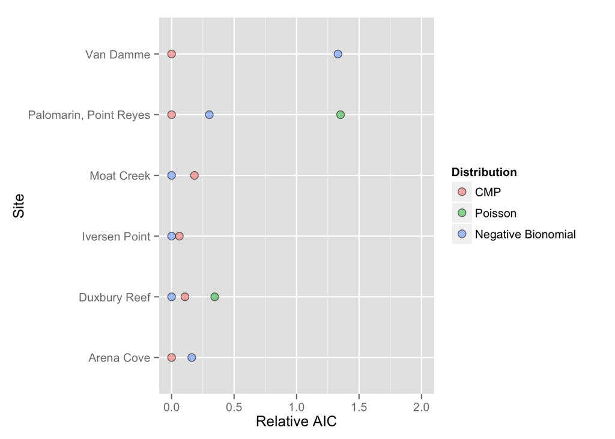

```r
ggplot(aictab, aes(x=rel_AIC, y=Site.Name, fill=distribution)) +
  geom_point(size=3, alpha=0.5, pch=21, col="black") +
  scale_fill_discrete(name="Distribution", labels=c("CMP", "Poisson", "Negative Bionomial")) +
  xlab("Relative AIC") + ylab("Site") +
  xlim(0,2)
```

The site vary in whether the Negative Binomial or CMP distributions predict the data better, but the difference is never above 2, which is the general rule-of-thumb for distinguishing between fits. So both fit this data equally well.

What did we learn? At least in this case, over-dispersed data seem to be modeled equally well by CMP or Negative Binomial distributions.